# Impact of Subgroup Misclassification on Detecting Heterogeneous Treatment Effects in *Staphylococcus aureus* Bacteremia: A Simulation Study

Author

Fergus Hamilton

Published

April 24, 2025

# 1 Abstract

**Background:** *Staphylococcus aureus* bacteremia (SAB) exhibits significant clinical heterogeneity. Recently identified subphenotypes show potential for heterogeneous treatment effects (HTE), but the impact of inevitable patient misclassification on detecting HTE is unclear.

**Methods:** We conducted a simulation study following the ADEMP framework (Aims, Data-generating mechanisms, Estimands, Methods, Performance measures). We simulated clinical trial data based on parameters from the ARREST trial (adjunctive rifampicin vs. placebo for SAB), incorporating five subphenotypes with differential treatment effects on 84-day mortality (Odds Ratios [ORs] from 0.3 to 18.8). We assessed: (1) statistical power for post-hoc subgroup analysis versus total trial size assuming perfect classification; (2) the impact of varying classification accuracy (50%-100%) on power, bias, MSE, and wrong-direction estimate rate in post-hoc analyses (fixed N=10,000); and (3) the Number Needed to Screen (NNS) and Number Needed to Randomize (NNR) to achieve 80% power in enrichment trials targeting specific subgroups, considering test accuracy. Simulations were repeated using more moderate (‘realistic’) ORs.

**Conclusions:** Detecting HTE in SAB is challenging. Post-hoc analyses require very large trials and high classification accuracy. Enrichment strategies can reduce NNR but face substantial screening burdens (NNS) heavily influenced by test accuracy and subgroup prevalence. Robust classification methods are crucial for advancing stratified medicine approaches in SAB.

# 2 Introduction

*Staphylococcus aureus* bacteremia (SAB) is a common and serious infection associated with significant morbidity and mortality (1). Globally, *S. aureus* is a leading cause of death due to bacterial pathogens and bacteremia (2). A defining feature of SAB is its clinical heterogeneity, encompassing variations in patient characteristics (e.g., age, comorbidities), pathogen factors (e.g., methicillin resistance), source of infection, and disease severity (1). Despite this heterogeneity, clinical trials in SAB often treat it as a single entity, potentially obscuring differential treatment effects within patient subgroups [(3); Holland2022]. Strategy trials investigating adjunctive or alternative therapies have frequently failed to show overall benefit compared to standard care [(3); Paulsen2024].

Recent efforts have focused on identifying clinically relevant subphenotypes within SAB to enable better patient stratification for research and potentially personalized treatment (4). Swets, Russell, et al. recently used latent class analysis on data from observational and trial cohorts (Edinburgh, ARREST, SAFO) to identify five distinct and reproducible clinical subphenotypes (A-E) based on routinely collected clinical data (5). Crucially, a secondary analysis of the ARREST trial (Adjunctive Rifampicin for *S. aureus* Bacteraemia) suggested potential heterogeneous treatment effects (HTE) of adjunctive rifampicin across these subphenotypes regarding 84-day mortality. Notably, rifampicin appeared potentially harmful in subphenotype B (Nosocomial IV catheter-associated SAB; OR 18.8) and potentially beneficial in subphenotype E (SAB associated with injecting drug use; OR 0.3) (5).

The possibility of such HTE raises critical questions for future clinical trial design and the implementation of stratified medicine approaches. If treatment effects truly differ between subgroups, accurately identifying these subgroups becomes paramount. However, any diagnostic test or classification algorithm used to assign patients to subphenotypes will inevitably have imperfect accuracy (6). Misclassifying patients can lead to biased estimates of subgroup-specific effects, reduced statistical power to detect true HTE, and potentially misleading conclusions about which patients benefit or are harmed by a treatment [(7); Sussman2017]. Understanding the quantitative impact of misclassification is essential for interpreting subgroup analyses and designing efficient trials, including potential enrichment strategies [(8); Simon2004].

This simulation study aims to quantify the impact of subgroup misclassification on detecting HTE in SAB, using the subphenotypes and treatment effects derived from the Swets et al. analysis of the ARREST trial as a motivating example. Specifically, we address three aims: 1. Estimate the total sample sizes required in a standard randomized controlled trial (RCT) to achieve adequate statistical power (80%) for post-hoc analyses of subgroup-specific treatment effects, assuming perfect patient classification. 2. Quantify the impact of varying levels of classification accuracy on statistical power, estimation bias, Mean Squared Error (MSE), and the probability of estimating effects in the wrong direction for both subgroup-specific and overall treatment effects in post-hoc analyses of a large (N=10,000) standard RCT. 3. Estimate the Number Needed to Screen (NNS) and the resulting average Number Needed to Randomize (NNR) within the enriched cohort required to achieve 80% power in a hypothetical enrichment trial design targeting specific subgroups, considering varying levels of test accuracy.

We structure the reporting of our simulation methods and results following the ADEMP framework (Aims, Data-generating mechanisms, Estimands, Methods, Performance measures) (9).

# 3 Methods

This simulation study was designed and reported following the ADEMP framework [(9); Siepe2024].

## 3.1 Aims

1. **Post-hoc Power vs. N:** To estimate the total sample size (`n`) required in a standard two-arm RCT to achieve 80% statistical power for detecting subgroup-specific treatment effects (based on ARREST trial ORs) in post-hoc analyses, assuming perfect classification (`accuracy`=1.0).
2. **Impact of Accuracy:** To quantify the impact of varying classification `accuracy` (0.5 to 1.0) on statistical power, bias, MSE, and the wrong-direction rate for estimating subgroup-specific and overall treatment effects in post-hoc analyses of a standard RCT with a fixed total sample size (`n`=10,000).
3. **Enrichment Trial Sample Sizes:** To estimate the Number Needed to Screen (NNS) and the average Number Needed to Randomize (NNR) within an enriched cohort required to achieve 80% power in a hypothetical enrichment trial targeting specific subgroups (B, C, E), using a screening test with varying `accuracy`.

## 3.2 Data-Generating Mechanisms (DGMs)

We simulated individual patient data for two-arm (control vs. treatment) RCTs. The core DGM involved the following steps for each simulated patient:

1. **True Subgroup Assignment:** Each patient was assigned a ‘true’ subgroup (A, B, C, D, or E) based on sampling from a multinomial distribution defined by the population prevalence (`freq_vector`).
2. **Treatment Assignment:** Patients were assigned to treatment (1) or control (0) with equal probability (0.5).
3. **Outcome Generation:** A binary outcome (‘success’, representing death by 84 days = 1, survival = 0) was generated based on the patient’s true subgroup, treatment assignment, the subgroup-specific baseline event probability in the control group (`p0_vector`), and the subgroup-specific treatment effect (odds ratio, `or_vector`). The probability of death for patient `i` in subgroup `j` receiving treatment `t` (0 or 1) was calculated using the logistic model: $P(\text{Death}_{ij} | \text{Treatment}=t) = \text{expit}(\text{logit}(p0_j) + \log(OR_j) \times t)$. The outcome was then drawn from a Bernoulli distribution with this probability.

**Parameterization:** Two main parameter sets were used: * **ARREST Scenario:** Based directly on the Swets et al. (5) analysis of the ARREST trial 84-day mortality data. * `or_vector`: `c(A = 1.0, B = 18.8, C = 0.79, D = 1.4, E = 0.3)` * `freq_vector`: `c(A = 60/388, B = 52/388, C = 138/388, D = 69/388, E = 69/388)` * `p0_vector_adjusted`: `c(A = 7/60, B = 0.5/(52+0.5), C = 11/138, D = 11/69, E = 1/69)`. Note the Haldane-Anscombe correction for subgroup B. * **Realistic Scenario:** Used more moderate ORs while keeping frequencies and baseline risks the same as the ARREST scenario. * `or_vector`: `c(A = 1.0, B = 2.0, C = 0.7, D = 1.2, E = 0.8)` * `freq_vector`: Same as ARREST. * `p0_vector_adjusted`: Same as ARREST.

**Misclassification / Testing Mechanism:** * For Aims 2 and 3, patient classification accuracy was simulated using the `misclassify_group` function. For each patient with true subgroup `j`, the assigned subgroup was set to `j` with probability `accuracy`. With probability `1 - accuracy`, the assigned subgroup was randomly sampled from the overall population distribution (`freq_vector`). This simulates a classification process where errors result in assignment proportional to overall prevalence.

## 3.3 Estimands

The target quantities (estimands) for each aim were:

- **Aim 1:** The statistical power to reject the null hypothesis of no treatment effect (OR=1) within each subgroup (A-E) in a post-hoc analysis, using a Bonferroni-corrected alpha level (0.05 / 5 = 0.01).
- **Aim 2:**
  - Primary: Statistical power (as in Aim 1, plus overall power at alpha=0.05).
  - Secondary: Bias (mean difference between estimated log(OR) and true log(OR)), Mean Squared Error (MSE) of the log(OR) estimate, and Wrong Direction Rate (percentage of estimates where sign(log(OR)) differs from sign(true log(OR))).
- **Aim 3:**
  - Primary: Number Needed to Screen (NNS) to achieve 80% power (alpha=0.05) in an enrichment trial for a target subgroup.
  - Secondary: Average Number Needed to Randomize (NNR) within the enriched cohort corresponding to the NNS achieving 80% power.

## 3.5 Performance Measures

The following performance measures were calculated by aggregating results across the `n_reps_global` replicates for each scenario:

## 3.6 Results

```r
# Define parameters based on ARREST trial data
or_mortality       <- c(A = 1.0, B = 18.8, C = 0.79, D = 1.4, E = 0.3)
freq_arrest        <- c(A = 60/388, B = 52/388, C = 138/388, D = 69/388, E = 69/388)
p0_arrest_raw      <- c(A = 7/60, B = 0/52, C = 11/138, D = 11/69, E = 1/69)

# Apply Haldane-Anscombe correction for subgroup B (0 events in control)
n0_B <- 52 # N in control group B from ARREST placebo
p0_B_corrected <- 0.5 / (n0_B + 0.5) # Corrected baseline probability
p0_arrest_adjusted <- p0_arrest_raw
p0_arrest_adjusted["B"] <- p0_B_corrected # Use corrected p0 for B (~0.0095)

# Simulation settings
n_reps_global      <- 10 # Final desired number of reps (increased from 10 for better stability)
sample_sizes       <- c(500, 1000, 2000, 3000, 5000, 7500, 10000, 15000, 20000) # For Aim 1
# Define screening sizes for Aim 3 (needs to cover expected NNS)
screen_sizes_aim3  <- c(1000, 2500, 5000, 7500, 10000, 15000, 20000, 30000, 40000, 50000, 75000, 100000, 150000, 200000)
accuracy_levels    <- seq(0.5, 1.0, by = 0.05) # For Aim 2 & Aim 3 test accuracy
n_fixed_aim2       <- 10000 # Sample size for Aim 2
alpha_bonferroni   <- 0.05 / 5 # Alpha for subgroup analyses (Aims 1 & 2)
alpha_overall      <- 0.05     # Alpha for overall analysis (Aim 2)
alpha_aim3         <- 0.05     # Alpha for enrichment trial analysis (Aim 3)
target_groups_aim3 <- c("B", "C", "E") # Target groups for enrichment

# Display target ORs for ARREST simulation
tibble(
  Subgroup = names(or_mortality),
  `Target OR (Mortality)` = or_mortality
) %>%
  gt() %>%
  tab_header(title = "Target Treatment Effects (ARREST ORs)") %>%
  fmt_number(columns = `Target OR (Mortality)`, decimals = 2)
```

Target Treatment Effects (ARREST ORs)

| Subgroup | Target OR (Mortality) |
| --- | --- |
| A | 1.00 |
| B | 18.80 |
| C | 0.79 |
| D | 1.40 |
| E | 0.30 |

### 3.6.1 Aim 1: Sample Size Requirements (Post-Hoc Analysis Power)

Simulations estimated the statistical power for post-hoc subgroup analyses within standard trials of increasing total size (`n_total`), assuming perfect classification.

```r
# Placeholder function if functions.R is not available
# Remove or replace if functions.R is sourced correctly
if (!exists("replicate_sims")) {
    replicate_sims <- function(or_vector, freq_vector, p0_vector, n, accuracy, n_reps, seed) {
        warning("Using placeholder 'replicate_sims'. Ensure functions.R is sourced.", call. = FALSE)
        # Return dummy data structure matching expected output
        groups <- c(names(or_vector), "Overall")
        expand_grid(rep = 1:n_reps, group = groups) %>%
            mutate(
                beta = rnorm(n(), mean=log(1), sd=0.5), # Dummy beta
                se = runif(n(), 0.1, 1), # Dummy SE
                pval = runif(n()) # Dummy p-value
            )
    }
}

# Run simulations for Aim 1 (No Caching)
# Setup parallel processing
n_cores_aim1 <- parallel::detectCores() - 1
if (n_cores_aim1 < 1) n_cores_aim1 <- 1
plan(multisession, workers = n_cores_aim1)
message(paste("Starting Aim 1 simulations using", n_cores_aim1, "cores..."))

results_aim1 <- future_map_dfr(sample_sizes, ~replicate_sims(
  or_vector  = or_mortality,
  freq_vector = freq_arrest, # Full population mix
  p0_vector  = p0_arrest_adjusted,
  n          = .x, # Total trial size
  accuracy   = 1.0, # Perfect classification for Aim 1
  n_reps     = n_reps_global,
  seed       = 1 # Consistent base seed for this aim
), .id = "size_id", .options = furrr_options(seed = TRUE)) %>%
  mutate(n_total = sample_sizes[as.numeric(size_id)])

# Shut down parallel workers
plan(sequential)
message("Aim 1 simulations complete.")

# Calculate power for each subgroup (Bonferroni corrected alpha for post-hoc)
power_aim1 <- results_aim1 %>%
  filter(group != "Overall") %>%
  mutate(pval = as.numeric(pval)) %>% # Ensure pval is numeric
  group_by(n_total, group) %>%
  summarise(power = mean(pval < alpha_bonferroni, na.rm = TRUE), .groups = "drop")

# Display power table
#| label: tbl-aim1-table-power
#| tbl-cap: "Aim 1: Power for Post-Hoc Subgroup Analysis vs. Total Trial Size (ARREST ORs, Perfect Classification)"
power_aim1 %>%
  mutate(power = scales::percent(power, accuracy = 1)) %>%
  pivot_wider(names_from = group, values_from = power) %>%
  gt() %>%
  cols_label(n_total = "Total Sample Size") %>%
  # tab_header(title = "Aim 1: Power for Post-Hoc Subgroup Analysis vs. Total Trial Size (ARREST ORs, Perfect Classification)") %>% # Redundant with caption
  tab_footnote(footnote = paste("Power calculated at Bonferroni-corrected alpha =", round(alpha_bonferroni, 3))) %>%
  fmt_percent(columns = where(is.character), scale_values = FALSE, decimals = 1) # Apply fmt_percent to character cols (pivoted power)
```

| Total Sample Size | A | B | C | D | E |
| --- | --- | --- | --- | --- | --- |
| 500 | 0% | 0% | 0% | 0% | 0% |
| 1000 | 0% | 40% | 0% | 0% | 0% |
| 2000 | 0% | 50% | 0% | 0% | 0% |
| 3000 | 0% | 80% | 0% | 30% | 0% |
| 5000 | 0% | 90% | 30% | 20% | 0% |
| 7500 | 0% | 100% | 0% | 40% | 0% |
| 10000 | 0% | 100% | 40% | 50% | 30% |
| 15000 | 0% | 100% | 30% | 80% | 60% |
| 20000 | 0% | 100% | 60% | 100% | 70% |

Power calculated at Bonferroni-corrected alpha = 0.01

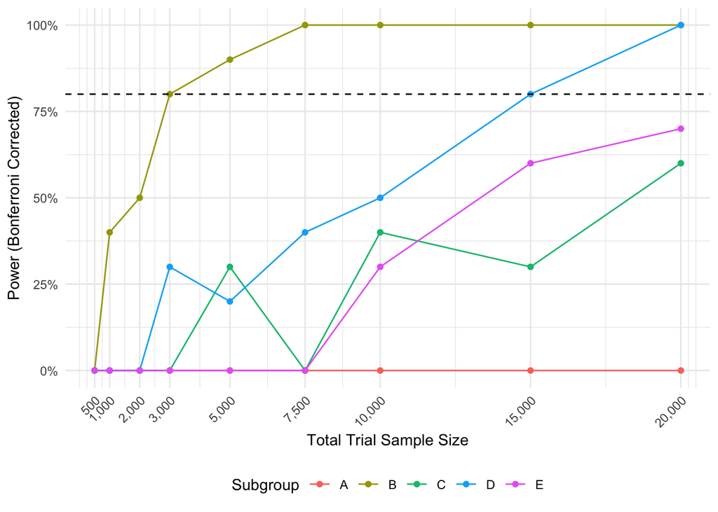

```r
# Display power plot
#| label: fig-aim1-plot-power
#| fig-cap: "Aim 1: Power for Post-Hoc Subgroup Analysis vs. Total Trial Size (ARREST ORs)"
ggplot(power_aim1, aes(x = n_total, y = power, color = group)) +
  geom_line() + geom_point() +
  geom_hline(yintercept = 0.8, linetype = "dashed") +
  scale_x_continuous(breaks = sample_sizes, labels = scales::comma) +
  scale_y_continuous(labels = scales::percent) +
  labs(
    # title = "Aim 1: Power for Post-Hoc Subgroup Analysis vs. Total Trial Size (ARREST ORs)", # Redundant with caption
    x = "Total Trial Sample Size",
    y = "Power (Bonferroni Corrected)",
    color = "Subgroup"
  ) +
  theme(axis.text.x = element_text(angle = 45, hjust = 1))
```

### 3.6.2 Aim 2: Impact of Classification Accuracy (Post-Hoc Analysis)

Simulations assessed the impact of varying classification accuracy on post-hoc analyses in a trial with N = 10^{4}.

```r
# Run simulations for Aim 2 (No Caching)
# Setup parallel processing
n_cores_aim2 <- parallel::detectCores() - 1
if (n_cores_aim2 < 1) n_cores_aim2 <- 1
plan(multisession, workers = n_cores_aim2)
message(paste("Starting Aim 2 simulations using", n_cores_aim2, "cores..."))

results_aim2 <- future_map_dfr(accuracy_levels, ~replicate_sims(
  or_vector  = or_mortality,
  freq_vector = freq_arrest, # Full population mix
  p0_vector  = p0_arrest_adjusted,
  n          = n_fixed_aim2, # Fixed total trial size
  accuracy   = .x,           # Varying accuracy
  n_reps     = n_reps_global,
  seed       = 2 # Consistent base seed for this aim
), .id = "acc_id", .options = furrr_options(seed = TRUE)) %>%
  mutate(accuracy = accuracy_levels[as.numeric(acc_id)])

# Shut down parallel workers
plan(sequential)
message("Aim 2 simulations complete.")


# Define the correct target betas (log ORs) for ARREST scenario
true_betas_arrest <- tibble(group = names(or_mortality), true_beta_target = log(or_mortality))
# Calculate expected overall beta (weighted average of log ORs)
# Note: This is an approximation, true overall effect depends on how misclassification impacts group sizes
true_beta_overall_arrest <- sum(log(or_mortality) * freq_arrest, na.rm = TRUE)
true_betas_arrest <- bind_rows(true_betas_arrest, tibble(group="Overall", true_beta_target = true_beta_overall_arrest))

# Join target betas and calculate per-replicate performance metrics
results_aim2_processed <- results_aim2 %>%
  mutate(beta = as.numeric(beta), pval = as.numeric(pval)) %>% # Ensure numeric types
  left_join(true_betas_arrest, by = "group") %>%
  mutate(
    # Determine significance based on group (subgroup vs overall alpha)
    is_significant = if_else(group == "Overall", pval < alpha_overall, pval < alpha_bonferroni),
    bias_val = beta - true_beta_target,
    mse_val = (beta - true_beta_target)^2,
    # Wrong direction if signs differ (handle true OR=1 case where target beta=0)
    wrong_dir_val = if_else(true_beta_target == 0, sign(beta) != 0, sign(beta) != sign(true_beta_target))
  )

# Summarise performance metrics across replicates
summary_aim2 <- results_aim2_processed %>%
  group_by(accuracy, group) %>%
  summarise(
    power     = mean(is_significant, na.rm = TRUE),
    bias      = mean(bias_val, na.rm = TRUE),
    mse       = mean(mse_val, na.rm = TRUE),
    wrong_dir = mean(wrong_dir_val, na.rm = TRUE) * 100, # As percentage
    n_reps_successful = sum(!is.na(pval)), # Count non-NA p-values
    .groups   = "drop"
  ) %>%
  # Ensure all combinations of accuracy and group are present
  complete(accuracy, group = c("A", "B", "C", "D", "E", "Overall")) %>%
  arrange(group, accuracy)

# Display summary table (long format)
#| label: tbl-aim2-table-summary-long
#| tbl-cap: "Aim 2: Post-Hoc Analysis Summary vs. Accuracy (ARREST ORs, Total N = 10,000)"
summary_aim2 %>%
  select(
    group,
    accuracy,
    Power = power,
    Bias = bias,
    MSE = mse,
    `Wrong Dir %` = wrong_dir
  ) %>%
  gt(groupname_col = "group") %>%
  fmt_percent(columns = Power, decimals = 1) %>%
  fmt_number(columns = c(Bias, MSE), decimals = 2) %>%
  fmt_percent(columns = `Wrong Dir %`, scale_values = FALSE, decimals = 1) %>%
  fmt_number(columns = accuracy, decimals = 2) %>%
  cols_label(
    accuracy = "Accuracy",
    Power = "Power",
    Bias = "Bias",
    MSE = "MSE",
    `Wrong Dir %` = "Wrong Dir %"
  ) %>%
  # Removed header - caption serves as title
  # tab_header(title = paste("Aim 2: Post-Hoc Analysis Summary vs. Accuracy (ARREST ORs, Total N =", n_fixed_aim2, ")")) %>%
  tab_options(row_group.font.weight = "bold")
```

| Accuracy | Power | Bias | MSE | Wrong Dir % |
| --- | --- | --- | --- | --- |
| A |  |  |  |  |
| 0.50 | 0.0% | 0.14 | 0.05 | 100.0% |
| 0.55 | 0.0% | 0.03 | 0.02 | 100.0% |
| 0.60 | 0.0% | 0.05 | 0.02 | 100.0% |
| 0.65 | 0.0% | 0.04 | 0.03 | 100.0% |
| 0.70 | 0.0% | 0.04 | 0.02 | 100.0% |
| 0.75 | 0.0% | 0.03 | 0.03 | 100.0% |
| 0.80 | 0.0% | 0.02 | 0.02 | 100.0% |
| 0.85 | 0.0% | 0.00 | 0.02 | 100.0% |
| 0.90 | 0.0% | 0.01 | 0.02 | 100.0% |
| 0.95 | 0.0% | 0.03 | 0.02 | 100.0% |
| 1.00 | 0.0% | 0.02 | 0.02 | 100.0% |
| B |  |  |  |  |
| 0.50 | 100.0% | −1.72 | 2.99 | 0.0% |
| 0.55 | 100.0% | −1.60 | 2.59 | 0.0% |
| 0.60 | 100.0% | −1.46 | 2.18 | 0.0% |
| 0.65 | 100.0% | −1.31 | 1.78 | 0.0% |
| 0.70 | 100.0% | −1.18 | 1.45 | 0.0% |
| 0.75 | 100.0% | −1.06 | 1.19 | 0.0% |
| 0.80 | 100.0% | −0.89 | 0.85 | 0.0% |
| 0.85 | 100.0% | −0.73 | 0.55 | 0.0% |
| 0.90 | 100.0% | −0.47 | 0.27 | 0.0% |
| 0.95 | 100.0% | −0.26 | 0.13 | 0.0% |
| 1.00 | 100.0% | 0.13 | 0.14 | 0.0% |
| C |  |  |  |  |
| 0.50 | 10.0% | 0.20 | 0.06 | 30.0% |
| 0.55 | 10.0% | 0.21 | 0.07 | 40.0% |
| 0.60 | 10.0% | 0.16 | 0.05 | 20.0% |
| 0.65 | 10.0% | 0.13 | 0.04 | 20.0% |
| 0.70 | 10.0% | 0.09 | 0.03 | 20.0% |
| 0.75 | 10.0% | 0.08 | 0.03 | 10.0% |
| 0.80 | 20.0% | 0.05 | 0.03 | 0.0% |
| 0.85 | 20.0% | 0.02 | 0.02 | 0.0% |
| 0.90 | 20.0% | −0.01 | 0.02 | 0.0% |
| 0.95 | 30.0% | −0.06 | 0.02 | 0.0% |
| 1.00 | 40.0% | −0.10 | 0.03 | 0.0% |
| D |  |  |  |  |
| 0.50 | 0.0% | −0.13 | 0.02 | 0.0% |
| 0.55 | 30.0% | −0.04 | 0.02 | 0.0% |
| 0.60 | 50.0% | −0.03 | 0.02 | 0.0% |
| 0.65 | 50.0% | −0.02 | 0.01 | 0.0% |
| 0.70 | 40.0% | −0.02 | 0.01 | 0.0% |
| 0.75 | 40.0% | −0.02 | 0.01 | 0.0% |
| 0.80 | 50.0% | −0.02 | 0.01 | 0.0% |
| 0.85 | 50.0% | −0.02 | 0.01 | 0.0% |
| 0.90 | 40.0% | −0.03 | 0.01 | 0.0% |
| 0.95 | 50.0% | −0.02 | 0.01 | 0.0% |
| 1.00 | 50.0% | −0.03 | 0.01 | 0.0% |
| E |  |  |  |  |
| 0.50 | 0.0% | 1.33 | 1.80 | 70.0% |
| 0.55 | 0.0% | 1.15 | 1.34 | 40.0% |
| 0.60 | 0.0% | 1.11 | 1.25 | 30.0% |
| 0.65 | 0.0% | 1.06 | 1.15 | 20.0% |
| 0.70 | 0.0% | 1.03 | 1.10 | 10.0% |
| 0.75 | 0.0% | 0.97 | 0.97 | 20.0% |
| 0.80 | 0.0% | 0.91 | 0.88 | 0.0% |
| 0.85 | 0.0% | 0.86 | 0.80 | 0.0% |
| 0.90 | 10.0% | 0.63 | 0.49 | 0.0% |
| 0.95 | 10.0% | 0.39 | 0.28 | 0.0% |
| 1.00 | 30.0% | 0.00 | 0.26 | 0.0% |
| Overall |  |  |  |  |
| 0.50 | 90.0% | 0.07 | 0.01 | 0.0% |
| 0.55 | 90.0% | 0.07 | 0.01 | 0.0% |
| 0.60 | 90.0% | 0.07 | 0.01 | 0.0% |
| 0.65 | 90.0% | 0.07 | 0.01 | 0.0% |
| 0.70 | 90.0% | 0.07 | 0.01 | 0.0% |
| 0.75 | 90.0% | 0.07 | 0.01 | 0.0% |
| 0.80 | 90.0% | 0.07 | 0.01 | 0.0% |
| 0.85 | 90.0% | 0.07 | 0.01 | 0.0% |
| 0.90 | 90.0% | 0.07 | 0.01 | 0.0% |
| 0.95 | 90.0% | 0.07 | 0.01 | 0.0% |
| 1.00 | 90.0% | 0.07 | 0.01 | 0.0% |

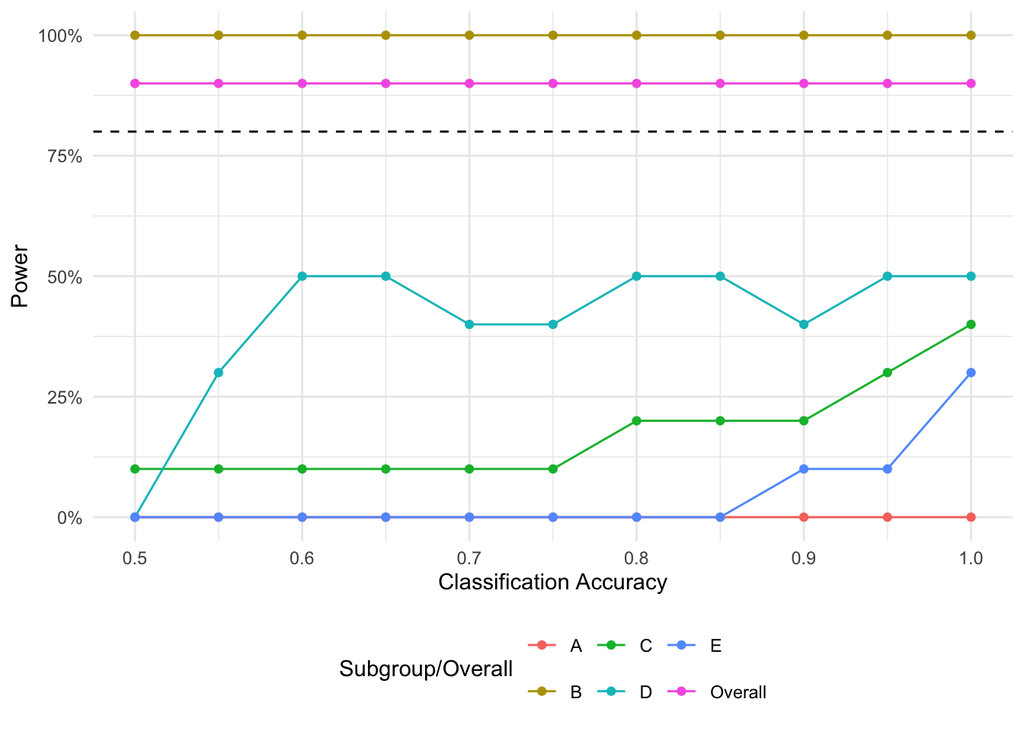

```r
# Plot Power vs Accuracy
#| label: fig-aim2-plot-power
#| fig-cap: "Aim 2: Post-Hoc Analysis Power vs Classification Accuracy (ARREST ORs, N = 10,000)"
ggplot(summary_aim2, aes(x = accuracy, y = power, color = group)) +
  geom_line() + geom_point() +
  geom_hline(yintercept = 0.8, linetype = "dashed") +
  scale_y_continuous(labels = scales::percent) +
  labs(
    # title = paste("Aim 2: Post-Hoc Analysis Power vs Accuracy (ARREST ORs, N =", n_fixed_aim2, ")"), # Redundant
    x     = "Classification Accuracy",
    y     = "Power",
    color = "Subgroup/Overall"
  )
```

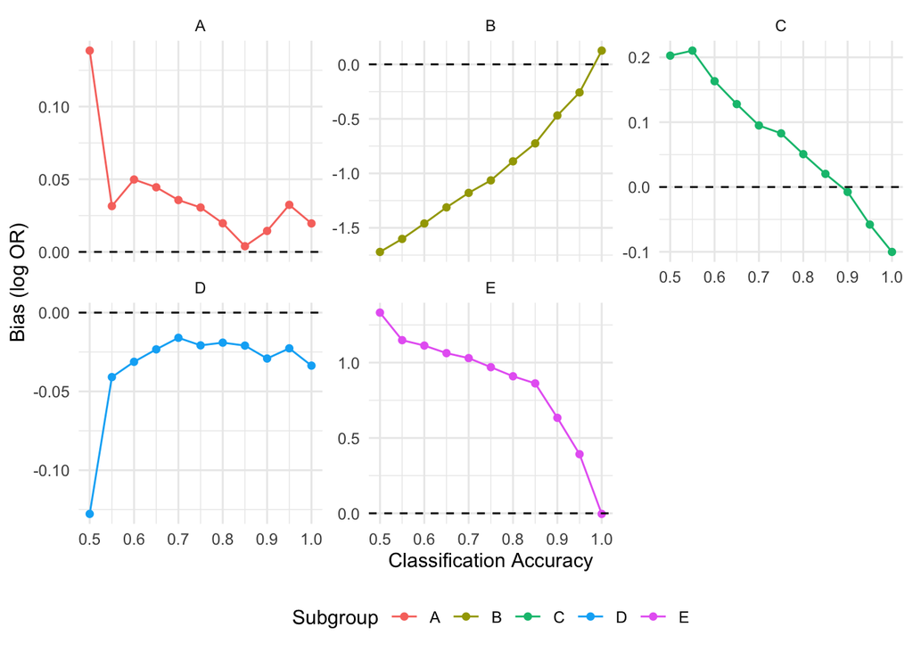

```r
# Plot Bias vs Accuracy
#| label: fig-aim2-plot-bias
#| fig-cap: "Aim 2: Post-Hoc Estimation Bias vs Classification Accuracy (ARREST ORs, N = 10,000)"
# Filter out Overall group for this plot as bias interpretation differs
ggplot(summary_aim2 %>% filter(group != "Overall"), aes(x = accuracy, y = bias, color = group)) +
  geom_line() + geom_point() +
  facet_wrap(~ group, scales = "free_y") + # Facet by group with free y-scales
  geom_hline(yintercept = 0, linetype = "dashed") + # Line at zero bias
  labs(
    # title = paste("Aim 2: Post-Hoc Estimation Bias vs Accuracy (ARREST ORs, N =", n_fixed_aim2, ")"), # Redundant
    x     = "Classification Accuracy",
    y     = "Bias (log OR)",
    color = "Subgroup"
  )
```

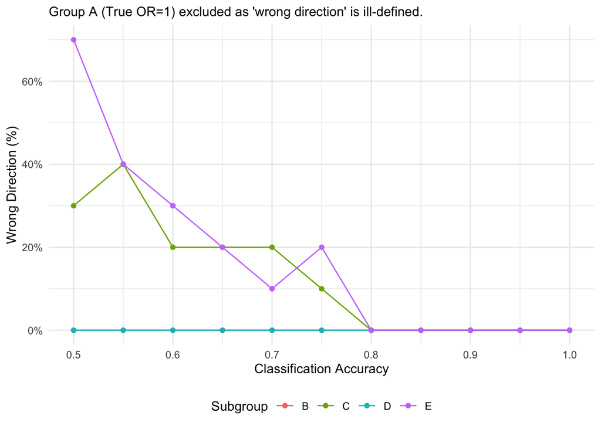

```r
# Plot Wrong Direction Rate vs Accuracy
#| label: fig-aim2-plot-wrong-direction
#| fig-cap: "Aim 2: Post-Hoc Wrong Direction % vs Classification Accuracy (ARREST ORs, N = 10,000)"
# Filter out Overall and Group A (true OR=1) for this plot
ggplot(summary_aim2 %>% filter(group != "Overall", group != "A"), aes(x = accuracy, y = wrong_dir, color = group)) +
  geom_line() + geom_point() +
  scale_y_continuous(labels = scales::percent_format(scale = 1)) + # Format y-axis as percentage
  labs(
    # title = paste("Aim 2: Post-Hoc Wrong Direction % vs Accuracy (ARREST ORs, N =", n_fixed_aim2, ")"), # Redundant
    subtitle = "Group A (True OR=1) excluded as 'wrong direction' is ill-defined.",
    x     = "Classification Accuracy",
    y     = "Wrong Direction (%)",
    color = "Subgroup"
  )
```

### 3.6.3 Aim 3: Sample Size Requirements (Enrichment Trial Simulation)

```r
# Function to run enrichment simulation replicates for one scenario
run_enrichment_scenario <- function(n_screened, target_group, accuracy,
                                    or_vector, p0_vector, freq_vector,
                                    n_reps, base_seed) {
  # Ensure freq_vector has names
  if(is.null(names(freq_vector))) names(freq_vector) <- LETTERS[1:length(freq_vector)]

  map_dfr(1:n_reps, ~{
    # Generate unique seed for this replicate
    seed <- base_seed + .x

    # 1. Simulate screened cohort using the full population mix
    screened_data <- simulate_trial_data(
      or_vector = or_vector,
      freq_vector = freq_vector, # Use the full population frequency
      n = n_screened,
      p0_vector = p0_vector,
      seed = seed
    )

    # 2. Apply test (misclassify) to the screened cohort
    # Assumes misclassify_group function is available (defined in setup)
    tested_data <- misclassify_group(
        screened_data,
        accuracy = accuracy,
        freq_vector = freq_vector, # Pass named freq_vector for sampling if incorrect
        seed = seed + n_reps # Use different seed offset for misclassification step
        )

    # 3. Select cohort for randomization ("test positives" for the target group)
    randomized_cohort <- tested_data %>% filter(assigned_group == target_group)
    n_randomized_actual <- nrow(randomized_cohort)

    # 4. Analyze the randomized cohort if it's large enough
    if(n_randomized_actual >= 10) { # Need minimum size for GLM stability
       analysis_results <- fit_glm_safe(randomized_cohort)
    } else {
       # If too small, return NA results
       analysis_results <- tibble(beta = NA_real_, se = NA_real_, pval = NA_real_)
    }

    # Return results for this replicate, including actual N randomized
    tibble(
        n_randomized_actual = n_randomized_actual
        ) %>% bind_cols(analysis_results)

  }, .id = "rep")
}

# Placeholder function if simulate_trial_data is not available from functions.R
if (!exists("simulate_trial_data")) {
    simulate_trial_data <- function(or_vector, freq_vector, n, p0_vector, seed = NULL) {
        warning("Using placeholder 'simulate_trial_data'. Ensure functions.R is sourced.", call. = FALSE)
        if(!is.null(seed)) set.seed(seed)
        # Return dummy data structure
        groups <- names(freq_vector)
        if(is.null(groups)) groups <- LETTERS[1:length(freq_vector)]
        tibble(
            id = 1:n,
            group = sample(groups, n, replace = TRUE, prob = freq_vector),
            treatment = rbinom(n, 1, 0.5),
            success = rbinom(n, 1, 0.2) # Dummy outcome
        )
    }
}


# --- Run Aim 3 Simulations ---
# Define parameter grid for Aim 3
aim3_params <- expand_grid(
    target_group = target_groups_aim3,
    accuracy = accuracy_levels, # Use same accuracy levels as Aim 2
    n_screened = screen_sizes_aim3
)

# Setup parallel processing using future and furrr
n_cores_aim3 <- parallel::detectCores() - 1
if (n_cores_aim3 < 1) n_cores_aim3 <- 1
plan(multisession, workers = n_cores_aim3)
message(paste("Starting Aim 3 simulations using", n_cores_aim3, "cores..."))

# Use future_pmap_dfr for parallel execution over the parameter grid
results_aim3 <- future_pmap_dfr(aim3_params, function(target_group, accuracy, n_screened) {
    # message(paste("Running Aim 3: Group", target_group, "Acc", accuracy, "N_screen", n_screened)) # Optional progress message
    run_enrichment_scenario(
        n_screened = n_screened,
        target_group = target_group,
        accuracy = accuracy,
        or_vector = or_mortality,       # ARREST ORs
        p0_vector = p0_arrest_adjusted, # ARREST baseline risks
        freq_vector = freq_arrest,      # ARREST frequencies
        n_reps = n_reps_global,
        # Ensure unique base seed for each scenario combination to avoid seed collision
        base_seed = 3000 + which(aim3_params$target_group == target_group & aim3_params$accuracy == accuracy & aim3_params$n_screened == n_screened) * n_reps_global
        ) %>%
    mutate( # Add parameters back for easy grouping later
        target_group = target_group,
        accuracy = accuracy,
        n_screened = n_screened
        )
}, .progress = TRUE, .options = furrr_options(seed = TRUE)) # Use progress bar and ensure seeds work correctly in parallel
```

[output not shown]

```r
# Shut down parallel workers
plan(sequential)
message("Aim 3 simulations complete. Processing results...")

# --- Process Aim 3 Results ---
# Calculate power and average N randomized for each scenario
summary_aim3 <- results_aim3 %>%
  mutate(pval = as.numeric(pval)) %>% # Ensure numeric
  group_by(target_group, accuracy, n_screened) %>%
  summarise(
    power = mean(pval < alpha_aim3, na.rm = TRUE), # Power at alpha=0.05 for enrichment
    mean_n_randomized = mean(n_randomized_actual, na.rm = TRUE),
    sd_n_randomized = sd(n_randomized_actual, na.rm = TRUE),
    n_reps_analyzed = sum(!is.na(pval)), # Count successful analyses
    .groups = "drop"
  )
```

[output not shown]

```r
# Find NNS required for 80% power for each target group and accuracy
nns_enrich <- summary_aim3 %>%
  group_by(target_group, accuracy) %>%
  arrange(n_screened) %>% # Order by N screened
  filter(power >= 0.8) %>% # Find scenarios meeting power threshold
  slice(1) %>% # Take the first (smallest N screened) that meets threshold
  select(target_group, accuracy, nns_needed_num = n_screened) %>% # Select the NNS
  ungroup() %>%
  # Ensure all combinations are present, even if power goal was not met within simulated range
  full_join(expand_grid(target_group = target_groups_aim3, accuracy = accuracy_levels), by = c("target_group", "accuracy")) %>%
  mutate(
    max_n_screened_aim3 = max(screen_sizes_aim3), # Max N screened in simulation
    # Format NNS nicely, indicating if > max simulated
    `N Needed to Screen (NNS)` = if_else(
      is.na(nns_needed_num), # If NA, power goal wasn't met
      paste(">", scales::comma(max_n_screened_aim3)), # Indicate > max
      scales::comma(nns_needed_num) # Format with comma
    )
  ) %>%
  select(target_group, accuracy, `N Needed to Screen (NNS)`, nns_needed_num) # Keep numeric NNS for joining
```

[output not shown]

```r
# Get the corresponding average NNR for the NNS found
nnr_enrich <- nns_enrich %>%
  # Join back to summary_aim3 only where NNS was determined (i.e., nns_needed_num is not NA)
  left_join(summary_aim3 %>% select(target_group, accuracy, n_screened, mean_n_randomized),
            by = c("target_group", "accuracy", "nns_needed_num" = "n_screened")) %>%
  mutate(`NNR (Enrichment)` = if_else(
      is.na(mean_n_randomized), # Check if join failed (i.e., power not reached)
      "-",                      # Indicate NNR not applicable
      scales::comma(round(mean_n_randomized), accuracy = 1) # Format NNR
      )) %>%
  select(target_group, accuracy, `NNR (Enrichment)`) # Select relevant columns
```

[output not shown]

```r
# Combine NNS and NNR results into a final table
implications_enrichment <- nns_enrich %>%
    left_join(nnr_enrich, by = c("target_group", "accuracy")) %>%
    # Add the target OR for context
    left_join(
        tibble(target_group = names(or_mortality), target_or = or_mortality) %>% filter(target_group %in% target_groups_aim3),
        by = "target_group"
    ) %>%
    select(
        Subgroup = target_group,
        `Target OR` = target_or,
        `Test Accuracy` = accuracy,
        `NNR (Enrichment)`, # Average N randomized in enriched cohort
        `N Needed to Screen (NNS)` # N screened from general pop
    ) %>%
    arrange(Subgroup, desc(`Test Accuracy`)) # Order for readability
```

[output not shown]

```r
# Plot power vs N Screened
#| label: fig-aim3-plot-power
#| fig-cap: "Aim 3: Power vs. N Screened in Enrichment Trial (Varying Test Accuracy)"
ggplot(summary_aim3, aes(x = n_screened, y = power, color = factor(accuracy))) +
  geom_line() + geom_point() +
  geom_hline(yintercept = 0.8, linetype = "dashed") + # 80% power line
  facet_wrap(~ target_group, scales = "free_x") + # Separate plot per target group
  scale_x_continuous(labels = scales::comma) + # Format x-axis
  scale_y_continuous(labels = scales::percent) + # Format y-axis
  labs(
    # title = "Aim 3: Power vs. N Screened in Enrichment Trial (Varying Accuracy)", # Redundant
    x = "N Screened",
    y = "Power (alpha = 0.05)",
    color = "Test Accuracy"
  ) +
  theme(axis.text.x = element_text(angle = 45, hjust = 1))
```

[output not shown]

[output not shown]

```r
# Plot NNS vs Accuracy
# Exclude ">" values for plotting (where power goal wasn't met)
plot_data_nns <- implications_enrichment %>%
  filter(str_detect(`N Needed to Screen (NNS)`, "^>", negate=TRUE)) %>%
  mutate(nns_numeric = as.numeric(gsub(",", "", `N Needed to Screen (NNS)`)))
```

[output not shown]

```r
ggplot(plot_data_nns, aes(x = `Test Accuracy`, y = nns_numeric, color = Subgroup)) +
  geom_line() + geom_point() +
  scale_y_log10(labels = scales::comma) + # Use log scale for NNS due to large range
  labs(title = NULL, #"NNS vs. Test Accuracy", # Redundant
       x = "Test Accuracy", y = "N Needed to Screen (Log Scale)") +
  theme(legend.position = 'bottom')
```

[output not shown]

[output not shown]

## 3.7 Supplementary: Realistic Effects

This section repeats the analyses using more plausible or ‘realistic’ effect sizes.

### 3.7.1 Supplementary Aim 1: Power vs. Sample Size (Realistic ORs)

```r
# Run simulations for Aim 1 (Realistic)
# Setup parallel processing
n_cores_aim1_real <- parallel::detectCores() - 1
if (n_cores_aim1_real < 1) n_cores_aim1_real <- 1
plan(multisession, workers = n_cores_aim1_real)
message(paste("Starting Realistic Aim 1 simulations using", n_cores_aim1_real, "cores..."))

results_aim1_real <- future_map_dfr(sample_sizes, ~replicate_sims(
  or_vector   = or_realistic,       # Use realistic ORs
  freq_vector = freq_arrest,
  n           = .x,
  p0_vector   = p0_arrest_adjusted, # Same baseline risks
  accuracy    = 1.0,                # Perfect classification
  n_reps      = n_reps_global,
  seed        = 4 # Different base seed for this scenario
), .id = "size_id", .options = furrr_options(seed = TRUE)) %>%
  mutate(n_total = sample_sizes[as.numeric(size_id)])

# Shut down parallel workers
plan(sequential)
message("Realistic Aim 1 simulations complete.")

# Calculate power
power_aim1_real <- results_aim1_real %>%
  filter(group != "Overall") %>%
  mutate(pval = as.numeric(pval)) %>%
  group_by(n_total, group) %>%
  summarise(power = mean(pval < alpha_bonferroni, na.rm = TRUE), .groups = "drop")

# Display power table
#| label: tbl-aim1-table-power-realistic
#| tbl-cap: "Supplementary: Power vs. Sample Size (Realistic ORs, Perfect Classification)"
power_aim1_real %>%
  mutate(power = scales::percent(power, accuracy = 1)) %>%
  pivot_wider(names_from = group, values_from = power) %>%
  gt() %>%
  cols_label(n_total = "Total Sample Size") %>%
  # tab_header(title = "Supplementary: Power vs. Sample Size (Realistic ORs, Perfect Classification)") %>%
  tab_footnote(footnote = paste("Power calculated at Bonferroni-corrected alpha =", round(alpha_bonferroni, 3))) %>%
  fmt_percent(columns = where(is.character), scale_values = FALSE, decimals = 1)
```

| Total Sample Size | A | B | C | D | E |
| --- | --- | --- | --- | --- | --- |
| 500 | 0% | 0% | 0% | 0% | 0% |
| 1000 | 0% | 0% | 0% | 0% | 0% |
| 2000 | 0% | 0% | 10% | 0% | 0% |
| 3000 | 0% | 0% | 20% | 0% | 0% |
| 5000 | 0% | 0% | 30% | 10% | 0% |
| 7500 | 0% | 0% | 30% | 0% | 0% |
| 10000 | 0% | 0% | 70% | 0% | 0% |
| 15000 | 0% | 20% | 70% | 20% | 0% |
| 20000 | 0% | 20% | 90% | 10% | 10% |

Power calculated at Bonferroni-corrected alpha = 0.01

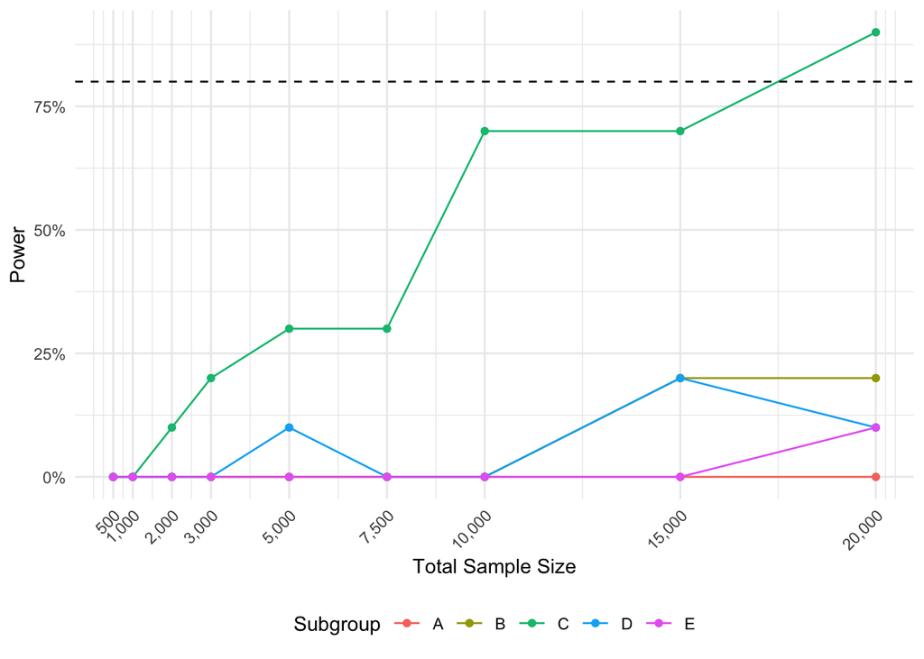

```r
# Display power plot
#| label: fig-aim1-plot-power-realistic
#| fig-cap: "Supplementary: Power vs. Sample Size (Realistic ORs)"
ggplot(power_aim1_real, aes(x = n_total, y = power, color = group)) +
  geom_line() + geom_point() +
  geom_hline(yintercept = 0.8, linetype = "dashed") +
  scale_x_continuous(breaks = sample_sizes, labels = scales::comma) +
  scale_y_continuous(labels = scales::percent) +
  labs(
    # title = "Supplementary: Power vs. Sample Size (Realistic ORs)",
    x     = "Total Sample Size",
    y     = "Power",
    color = "Subgroup"
  ) +
  theme(axis.text.x = element_text(angle = 45, hjust = 1))
```

### 3.7.2 Supplementary Aim 2: Power vs. Accuracy (Realistic ORs)

```r
# Run simulations for Aim 2 (Realistic)
# Setup parallel processing
n_cores_aim2_real <- parallel::detectCores() - 1
if (n_cores_aim2_real < 1) n_cores_aim2_real <- 1
plan(multisession, workers = n_cores_aim2_real)
message(paste("Starting Realistic Aim 2 simulations using", n_cores_aim2_real, "cores..."))

results_aim2_real <- future_map_dfr(accuracy_levels, ~replicate_sims(
  or_vector   = or_realistic,       # Use realistic ORs
  freq_vector = freq_arrest,
  n           = n_fixed_aim2,       # Fixed N
  p0_vector   = p0_arrest_adjusted,
  accuracy    = .x,                 # Varying accuracy
  n_reps      = n_reps_global,
  seed        = 5 # Different base seed
), .id = "acc_id", .options = furrr_options(seed = TRUE)) %>%
  mutate(accuracy = accuracy_levels[as.numeric(acc_id)])

# Shut down parallel workers
plan(sequential)
message("Realistic Aim 2 simulations complete.")

# Define and join correct target betas for realistic ORs
true_betas_realistic <- tibble(group = names(or_realistic), true_beta_target = log(or_realistic))
true_beta_overall_realistic <- sum(log(or_realistic) * freq_arrest, na.rm = TRUE) # Approx overall
true_betas_realistic <- bind_rows(true_betas_realistic, tibble(group="Overall", true_beta_target = true_beta_overall_realistic))

# Join target betas and calculate per-replicate metrics
results_aim2_real_processed <- results_aim2_real %>%
  mutate(beta = as.numeric(beta), pval = as.numeric(pval)) %>%
  left_join(true_betas_realistic, by = "group") %>%
  mutate(
    is_significant = if_else(group == "Overall", pval < alpha_overall, pval < alpha_bonferroni),
    bias_val = beta - true_beta_target,
    mse_val = (beta - true_beta_target)^2,
    wrong_dir_val = if_else(true_beta_target == 0, sign(beta) != 0, sign(beta) != sign(true_beta_target))
  )

# Summarise across replicates
summary_aim2_real <- results_aim2_real_processed %>%
  group_by(accuracy, group) %>%
  summarise(
    power     = mean(is_significant, na.rm = TRUE),
    bias      = mean(bias_val, na.rm = TRUE),
    mse       = mean(mse_val, na.rm = TRUE),
    wrong_dir = mean(wrong_dir_val, na.rm = TRUE) * 100,
    .groups   = "drop"
  ) %>%
  complete(accuracy, group = c("A", "B", "C", "D", "E", "Overall")) %>%
  arrange(group, accuracy)

# Display summary table (long format)
#| label: tbl-aim2-table-summary-long-realistic
#| tbl-cap: "Supplementary: Simulation Summary vs. Accuracy (Realistic ORs, N = 10,000)"
summary_aim2_real %>%
  select(
    group,
    accuracy,
    Power = power,
    Bias = bias,
    MSE = mse,
    `Wrong Dir %` = wrong_dir
  ) %>%
  gt(groupname_col = "group") %>%
  fmt_percent(columns = Power, decimals = 1) %>%
  fmt_number(columns = c(Bias, MSE), decimals = 2) %>%
  fmt_percent(columns = `Wrong Dir %`, scale_values = FALSE, decimals = 1) %>%
  fmt_number(columns = accuracy, decimals = 2) %>%
  cols_label(
    accuracy = "Accuracy",
    Power = "Power",
    Bias = "Bias",
    MSE = "MSE",
    `Wrong Dir %` = "Wrong Dir %"
  ) %>%
  # tab_header(title = paste("Supplementary: Simulation Summary vs. Accuracy (Realistic ORs, N =", n_fixed_aim2, ")")) %>%
  tab_options(row_group.font.weight = "bold")
```

| Accuracy | Power | Bias | MSE | Wrong Dir % |
| --- | --- | --- | --- | --- |
| A |  |  |  |  |
| 0.50 | 0.0% | 0.06 | 0.03 | 100.0% |
| 0.55 | 0.0% | −0.02 | 0.03 | 100.0% |
| 0.60 | 0.0% | 0.01 | 0.03 | 100.0% |
| 0.65 | 0.0% | 0.02 | 0.03 | 100.0% |
| 0.70 | 0.0% | 0.01 | 0.03 | 100.0% |
| 0.75 | 0.0% | 0.01 | 0.03 | 100.0% |
| 0.80 | 0.0% | 0.02 | 0.03 | 100.0% |
| 0.85 | 0.0% | 0.02 | 0.03 | 100.0% |
| 0.90 | 0.0% | 0.01 | 0.02 | 100.0% |
| 0.95 | 0.0% | 0.04 | 0.02 | 100.0% |
| 1.00 | 0.0% | 0.05 | 0.02 | 100.0% |
| B |  |  |  |  |
| 0.50 | 0.0% | −0.49 | 0.28 | 20.0% |
| 0.55 | 0.0% | −0.45 | 0.26 | 10.0% |
| 0.60 | 10.0% | −0.39 | 0.23 | 10.0% |
| 0.65 | 10.0% | −0.39 | 0.26 | 10.0% |
| 0.70 | 10.0% | −0.33 | 0.23 | 0.0% |
| 0.75 | 20.0% | −0.24 | 0.24 | 20.0% |
| 0.80 | 20.0% | −0.17 | 0.21 | 10.0% |
| 0.85 | 10.0% | −0.20 | 0.15 | 0.0% |
| 0.90 | 10.0% | −0.08 | 0.21 | 10.0% |
| 0.95 | 10.0% | −0.12 | 0.17 | 10.0% |
| 1.00 | 10.0% | 0.11 | 0.26 | 0.0% |
| C |  |  |  |  |
| 0.50 | 30.0% | 0.09 | 0.02 | 0.0% |
| 0.55 | 30.0% | 0.13 | 0.04 | 10.0% |
| 0.60 | 30.0% | 0.10 | 0.04 | 10.0% |
| 0.65 | 20.0% | 0.07 | 0.03 | 0.0% |
| 0.70 | 40.0% | 0.04 | 0.03 | 0.0% |
| 0.75 | 40.0% | 0.02 | 0.02 | 0.0% |
| 0.80 | 40.0% | 0.03 | 0.02 | 0.0% |
| 0.85 | 60.0% | 0.00 | 0.02 | 0.0% |
| 0.90 | 60.0% | −0.01 | 0.02 | 0.0% |
| 0.95 | 60.0% | −0.04 | 0.01 | 0.0% |
| 1.00 | 60.0% | −0.07 | 0.02 | 0.0% |
| D |  |  |  |  |
| 0.50 | 0.0% | −0.10 | 0.02 | 10.0% |
| 0.55 | 0.0% | −0.12 | 0.02 | 10.0% |
| 0.60 | 0.0% | −0.11 | 0.02 | 20.0% |
| 0.65 | 0.0% | −0.07 | 0.01 | 10.0% |
| 0.70 | 0.0% | −0.06 | 0.01 | 0.0% |
| 0.75 | 0.0% | −0.05 | 0.01 | 10.0% |
| 0.80 | 0.0% | −0.06 | 0.02 | 10.0% |
| 0.85 | 0.0% | −0.04 | 0.01 | 10.0% |
| 0.90 | 0.0% | −0.03 | 0.01 | 10.0% |
| 0.95 | 0.0% | −0.01 | 0.01 | 0.0% |
| 1.00 | 0.0% | −0.01 | 0.01 | 10.0% |
| E |  |  |  |  |
| 0.50 | 0.0% | 0.16 | 0.05 | 30.0% |
| 0.55 | 0.0% | 0.13 | 0.06 | 30.0% |
| 0.60 | 0.0% | 0.11 | 0.06 | 40.0% |
| 0.65 | 0.0% | 0.06 | 0.03 | 20.0% |
| 0.70 | 0.0% | 0.07 | 0.05 | 20.0% |
| 0.75 | 0.0% | 0.07 | 0.04 | 10.0% |
| 0.80 | 0.0% | 0.04 | 0.04 | 30.0% |
| 0.85 | 0.0% | 0.06 | 0.07 | 30.0% |
| 0.90 | 0.0% | −0.02 | 0.10 | 30.0% |
| 0.95 | 0.0% | −0.04 | 0.11 | 20.0% |
| 1.00 | 0.0% | −0.02 | 0.18 | 40.0% |
| Overall |  |  |  |  |
| 0.50 | 10.0% | −0.01 | 0.01 | 20.0% |
| 0.55 | 10.0% | −0.01 | 0.01 | 20.0% |
| 0.60 | 10.0% | −0.01 | 0.01 | 20.0% |
| 0.65 | 10.0% | −0.01 | 0.01 | 20.0% |
| 0.70 | 10.0% | −0.01 | 0.01 | 20.0% |
| 0.75 | 10.0% | −0.01 | 0.01 | 20.0% |
| 0.80 | 10.0% | −0.01 | 0.01 | 20.0% |
| 0.85 | 10.0% | −0.01 | 0.01 | 20.0% |
| 0.90 | 10.0% | −0.01 | 0.01 | 20.0% |
| 0.95 | 10.0% | −0.01 | 0.01 | 20.0% |
| 1.00 | 10.0% | −0.01 | 0.01 | 20.0% |

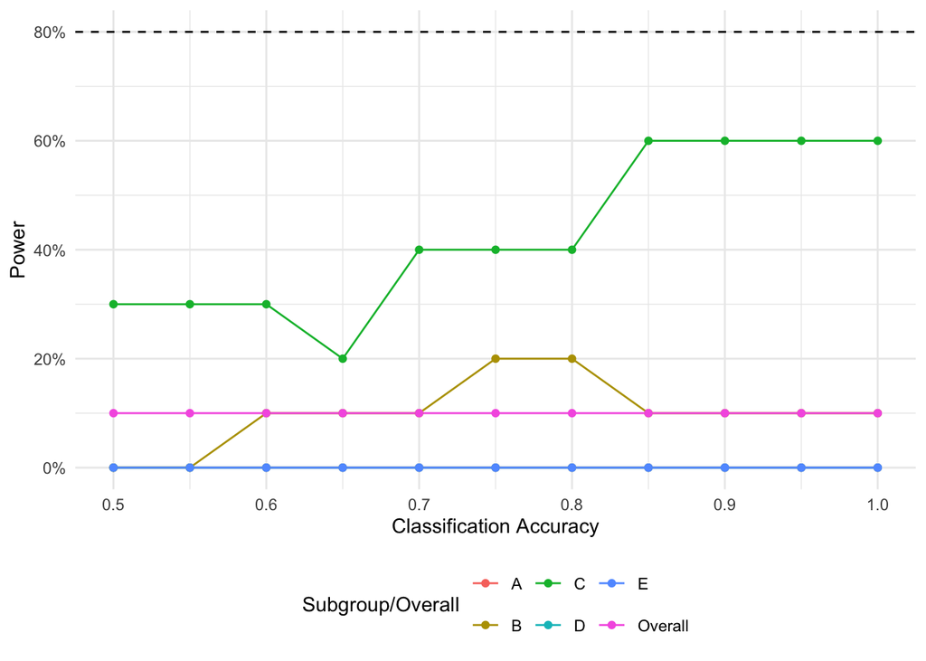

```r
# Plot Power vs Accuracy
#| label: fig-aim2-plot-power-realistic
#| fig-cap: "Supplementary: Power vs Accuracy (Realistic ORs, N = 10,000)"
ggplot(summary_aim2_real, aes(x = accuracy, y = power, color = group)) +
  geom_line() + geom_point() +
  geom_hline(yintercept = 0.8, linetype = "dashed") +
  scale_y_continuous(labels = scales::percent) +
  labs(
    # title = paste("Supplementary: Power vs Accuracy (Realistic; n =", n_fixed_aim2, ")"),
    x     = "Classification Accuracy",
    y     = "Power",
    color = "Subgroup/Overall"
  )
```

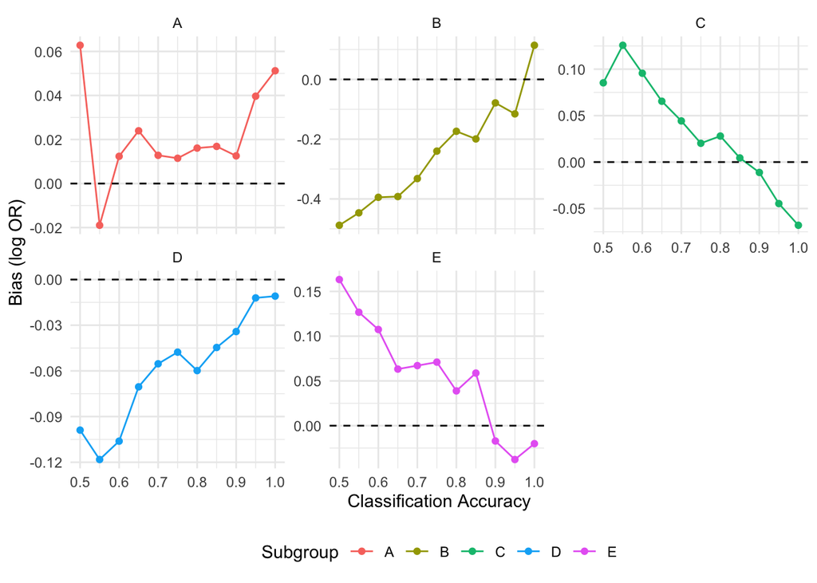

```r
# Plot Bias vs Accuracy
#| label: fig-aim2-plot-bias-realistic
#| fig-cap: "Supplementary: Estimation Bias vs Accuracy (Realistic ORs, N = 10,000)"
# Filter out Overall group
ggplot(summary_aim2_real %>% filter(group != "Overall"), aes(x = accuracy, y = bias, color = group)) +
  geom_line() + geom_point() +
  facet_wrap(~ group, scales = "free_y") +
  geom_hline(yintercept = 0, linetype = "dashed") +
  labs(
    # title = paste("Supplementary: Estimation Bias vs Accuracy (Realistic; n =", n_fixed_aim2, ")"),
    x     = "Classification Accuracy",
    y     = "Bias (log OR)",
    color = "Subgroup"
  )
```

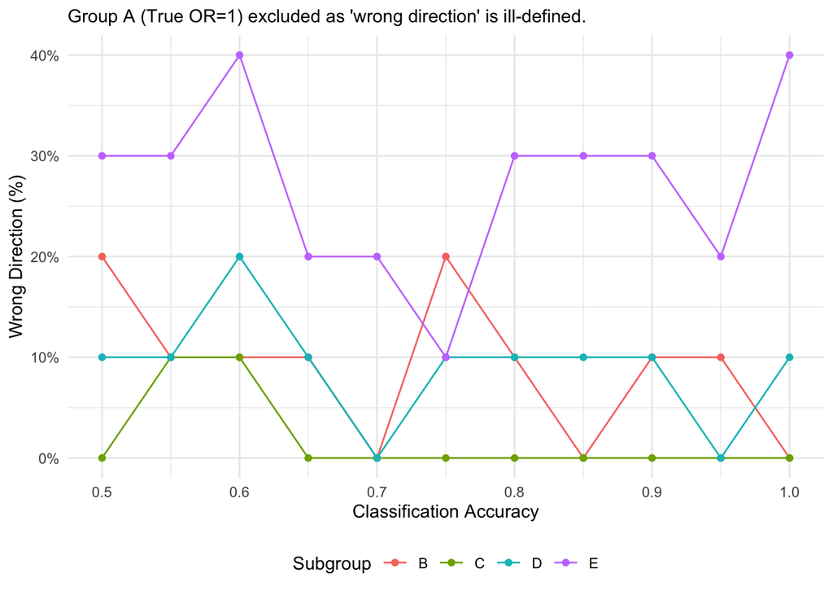

```r
# Plot Wrong Direction Rate vs Accuracy
#| label: fig-aim2-plot-wrong-direction-realistic
#| fig-cap: "Supplementary: Wrong Direction % vs Accuracy (Realistic ORs, N = 10,000)"
# Filter out Overall and Group A
ggplot(summary_aim2_real %>% filter(group != "Overall", group != "A"), aes(x = accuracy, y = wrong_dir, color = group)) +
  geom_line() + geom_point() +
  scale_y_continuous(labels = scales::percent_format(scale = 1)) +
  labs(
    # title = paste("Supplementary: Wrong Direction % vs Accuracy (Realistic; n =", n_fixed_aim2, ")"),
    subtitle = "Group A (True OR=1) excluded as 'wrong direction' is ill-defined.",
    x     = "Classification Accuracy",
    y     = "Wrong Direction (%)",
    color = "Subgroup"
  )
```